# YorkU Salary Comparison

Alex Filazzola

May 2017

In an attempt to correct some of York University’s portrayal of the CUPE3903 members as having unrealistic expectations in barganing (see this Memorandum), I thought it would be a good opportunity to review the prioritization of funding. More specifically, the salaries of employees on the [Sunshine List](https://www.ontario.ca/page/public-sector-salary-disclosure) and other relevant statistics. I know that this strike is about significantly more than a wage increase. If you think otherwise, I would encourage you to read the Union’s priorities in bargaining [Bargaining proposals](https://3903.cupe.ca/bargaining/). However, I thought I would offer a small rebuttle to these emails.

**Disclaimer**: I have removed the identifying names of individuals from these datasets. Although these names can be obtained through the online public database, my intention here is not to shame individuals for making a high salary. Many of the individuals included in this dataset are exceptionally well-trained, with many years experience, and high degrees of certification. My point in using this data is for a comparison to determine if there is a disparity in the treatment of CUPE3903 members relative to other areas.

### load data and libraries

```r
## load libraries
library(tidyverse)
library(readr)
library(ggthemes)
source("functions.R")

dat2012 <- read.csv("Data//2012.csv")
dat2013 <- read.csv("Data//2013.csv")
dat2014 <- read.csv("Data//2014.csv")
dat2015 <- read.csv("Data//2015.csv")
dat2016 <- read.csv("Data//2016.csv")

data <- rbind(dat2012,dat2013, dat2014, dat2015, dat2016)

data[,"Salary.Paid"] <- parse_number(data$Salary.Paid) ## convert dollarsigns to numbers
data[,"Calendar.Year"] <- as.factor(data$Calendar.Year) ## convert year to a factor
```

### Average Salary for the last 5 years

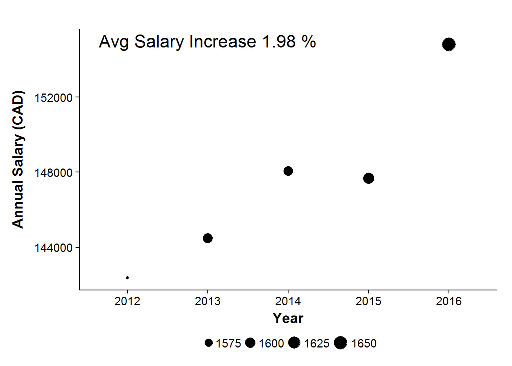

```r
## Calculate average salaries over the last 5 years
mean.paid <- data %>% group_by(Calendar.Year) %>% summarize(salary=mean(Salary.Paid), n=length(Salary.Paid))

## calculate average percent increase in salary
per.change <- round(mean(diff(mean.paid$salary)/mean.paid$salary*100),2)
text.lab <- paste("Avg Salary Increase",per.change,"%")

ggplot(data=mean.paid, aes(x=Calendar.Year, y=salary, size=n)) + geom_point() + theme_Publication() + ylab("Annual Salary (CAD)") + xlab("Year") + annotate("text", x= 2,y=155000, label=text.lab, size=6)
```

Over a five-year period, the average salary for employees at York University earning over 100,000 dollars increased 1.98%. Although this number may appear smaller relative to the amount York is offering CUPE3903 members (i.e. 2.1%), there is an increase in the number of individuals that earn over 100,000 (5% over the same time period). The individuals who crossed the threshold of 100,000 are essentially lowering the average salary change and thus 1.98% is a conservative estimate. Let’s remember too that during this same period of 2014-2016, CUPE3903 members received ~1.48% increase - [collective agreement](https://3903.cupe.ca/files/2012/03/92365-1-YU-Unit-1.pdf). Let’s also keep in perspective that a 1.98% increase for someone who is earning over 100,000 dollars means something much different than for the many graduate students that live below the poverty line.

But wait! The individuals within this comparison represent much of our teaching staff, lecturers, librarians, and the many different forms of adminstrative suport that we have. What about our upper administration, such as the executives, VPs, presidents, and provost positions? Surely as the decision makers of our University their own salary increases would match those they expect of their employees. Let’s take a look

### Upper-administration salary change

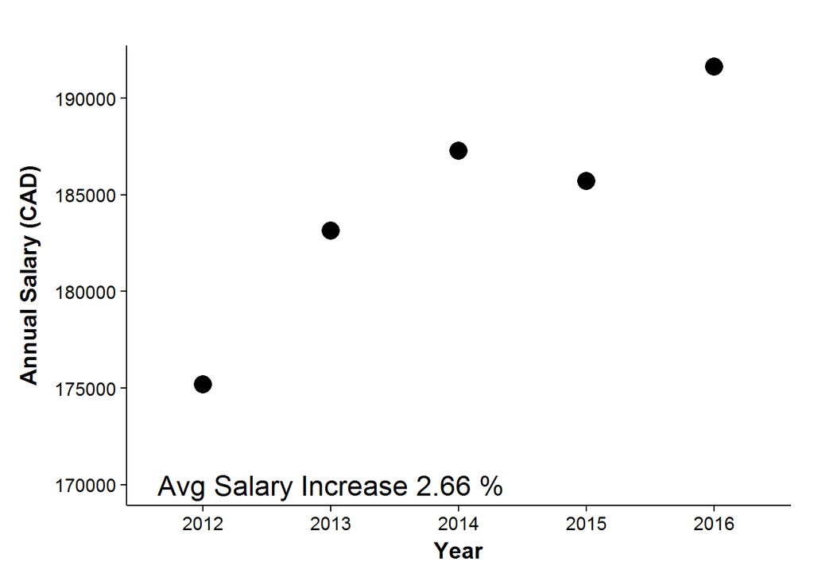

```r
## identify rows that are not teaching staff, professors, lower management, engineers, or technicians
exec <- as.numeric(rownames(data[grep("Executive", data$Job.Title), ])) ## executives, CEO, CTO, etc...
pres <- as.numeric(rownames(data[grep("President", data$Job.Title), ])) ## presidents and vice-presidents for each division
prov <- as.numeric(rownames(data[grep("Provost", data$Job.Title), ])) ## provost & vice-provost positions

## combine into a list
upperadmin <- c(exec,pres,prov)

## remove from data to be upper-admin positions only
admin <- data[upperadmin,]

## Calculate average salaries over the last 5 years
mean.paid <- admin %>% group_by(Calendar.Year) %>% summarize(salary=mean(Salary.Paid, n=length(Salary.Paid)))


## calculate average percent increase in salary
per.change <- round(mean(diff(mean.paid$salary)/mean.paid$salary*100),2)
text.lab <- paste("Avg Salary Increase",per.change,"%")

ggplot(data=mean.paid, aes(x=Calendar.Year, y=salary)) + geom_point(size=5) + theme_Publication() + ylab("Annual Salary (CAD)") + xlab("Year") + annotate("text", x= 2,y=170000, label=text.lab, size=6)
```

Interesting. Some of the highest salaried individuals at the University, many of those that are the decision makers, have also the highest percent increase in salary.

### Putting things into perspective

This strike has not been about salary. The Union has multiple proposals, such as equality in the workplace, that essentially cost the University zero dollars to implement, but are still met with pushback. The Union has revised many of the proposals to try and meet the University in the middle, but instead the University chooses to broadcast emails highlting the best of their proposals now and the most-costly of the Union’s proposals 6 months ago. I believe this stike is about many things, but if I had to pick three major themes, it would be consistency in pay throughout the year for Unit 1, conversion to full-time faculty for Unit 2, and the union-busting of Unit 3. I would request, as many others have, that the University return to the bargainning table with a more realistic expectations and stop with the distorting the truth.

### Want some more stats?

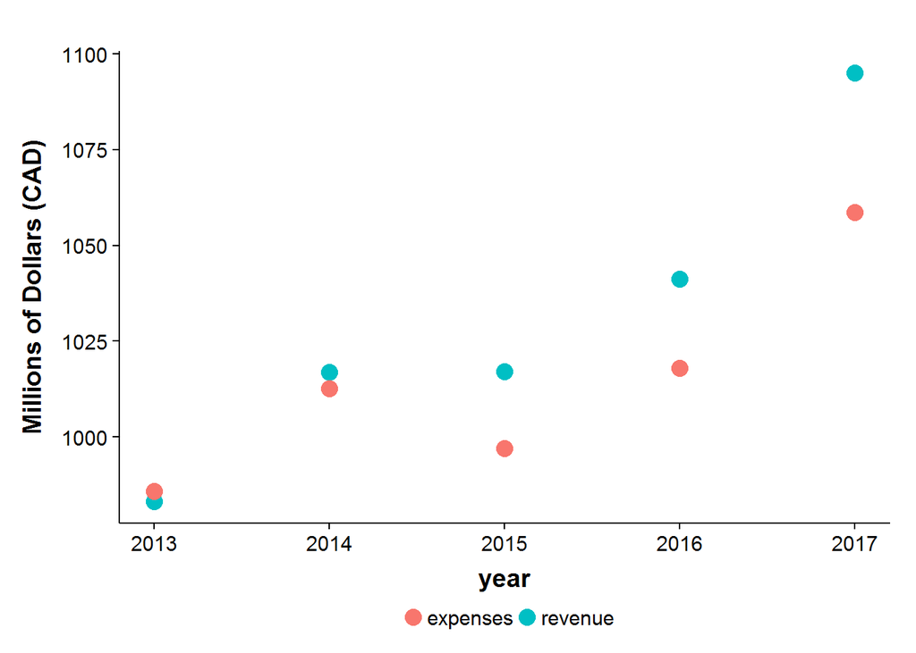

```r
rev.exp <- data.frame(year=c(2017,2016,2015,2014,2013,2017,2016,2015,2014,2013),dollars = c(1095.1,1041.2,1017.0,1016.9,983.1,1058.7,1017.9,997.1,1012.6,985.9), type=c(rep("revenue",5),rep("expenses",5)))

ggplot(data=rev.exp, aes(x=year, y=dollars, fill=type, color=type)) + geom_point(size=4) +theme_Publication() + ylab("Millions of Dollars (CAD)")
```